# Exploratory Data Analysis

K.D

2026-04-21

## Introduction

This document highlights some preliminary EDA which uncovers interesting patterns in the margin data. In addition, we explore the foundations of the filtering process to extract the cyclical component of our business cycle indicators.

As a reminder, **GOP margins** are defined as:

$$\text{GOP Margin} = \frac{\text{Gross Operating Profit}}{\text{Sales}}$$

While **GOS margins** are defined as:

$$\text{GOS Margin} = \frac{\text{Gross Operating Surplus}}{\text{Gross
Value Added}}$$

Given that these measures are constructed from different underlying aggregates, they display differing sensitivity to fluctuations in business conditions, resulting in distinct margin dynamics over the business cycle.

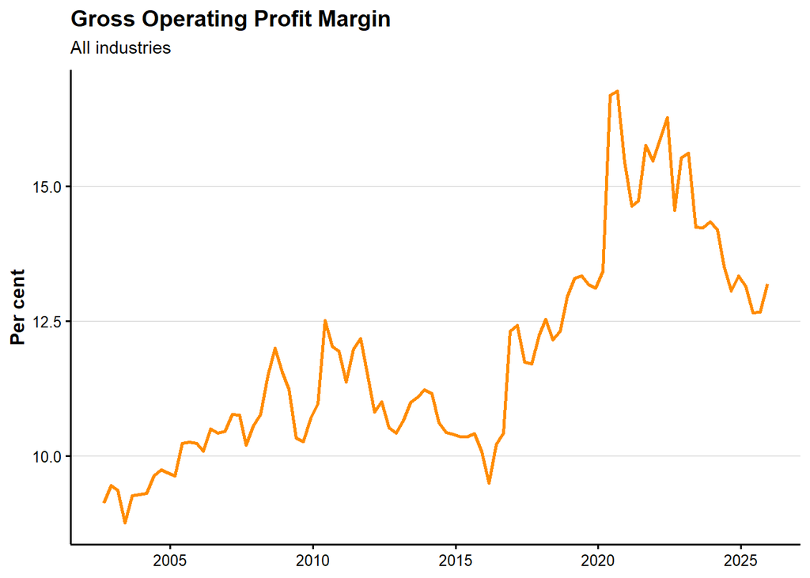

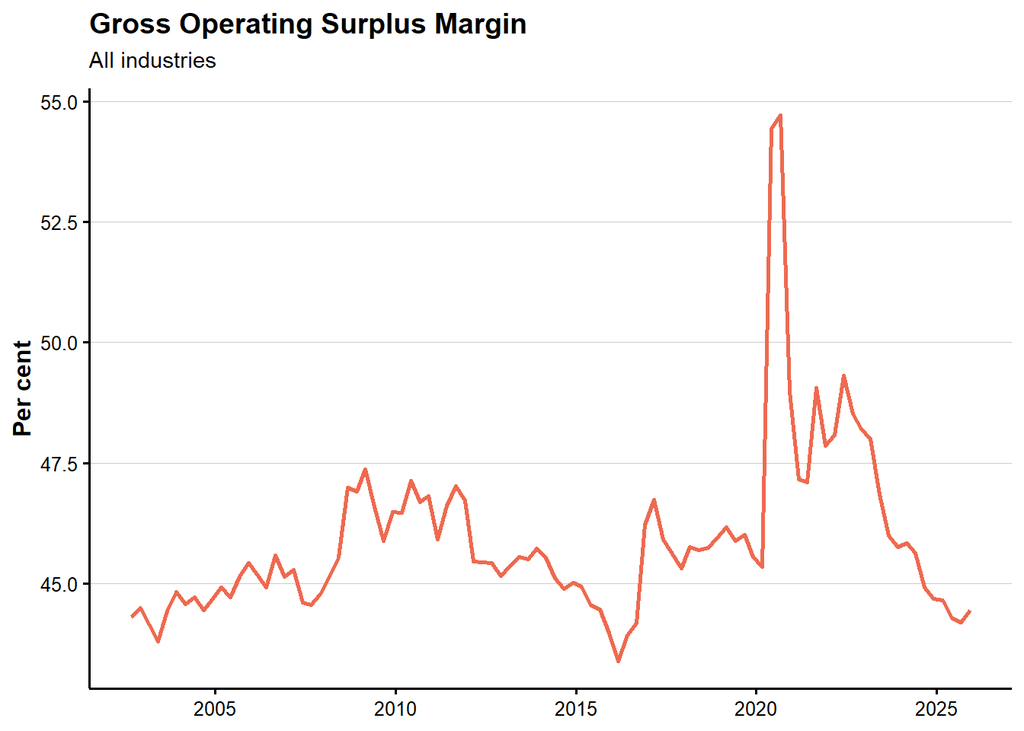

*These plots highlight the Total aggregate, which is an average of the profit margin across all selected industries (See Appendix 1.A).

## Descriptive statistics

```r
desc_stats_ts(gop_wide, value_col = Total)
```

```
## # A tibble: 1 × 7
##    mean    sd   min   p25 median   p75   max
##   <dbl> <dbl> <dbl> <dbl>  <dbl> <dbl> <dbl>
## 1  11.9  1.96  8.76  10.4   11.3  13.1  16.8
```

```r
desc_stats_ts(gos_wide, value_col = Total)
```

```
## # A tibble: 1 × 7
##    mean    sd   min   p25 median   p75   max
##   <dbl> <dbl> <dbl> <dbl>  <dbl> <dbl> <dbl>
## 1  45.9  1.78  43.4  44.8   45.5  46.6  54.7
```

`GOP` margins are lower on average (11.85%) than `GOS` margins (45.87%). This may highlight more variability in operating profits or sales over time, as they are more susceptible to changes in economic conditions.

## Distribution Highlights

These plots track profit margins across all selected industries, particularly highlighting the Total aggregate

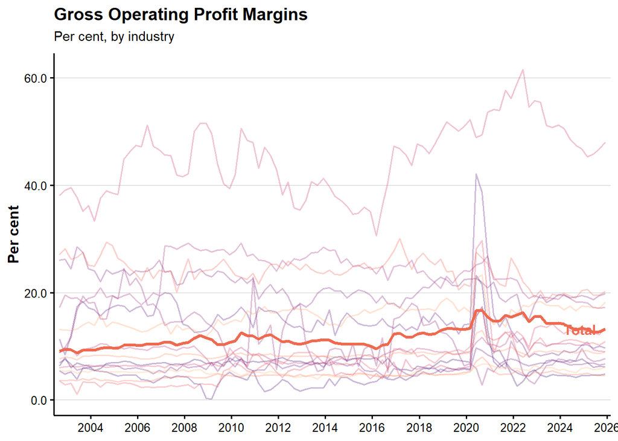

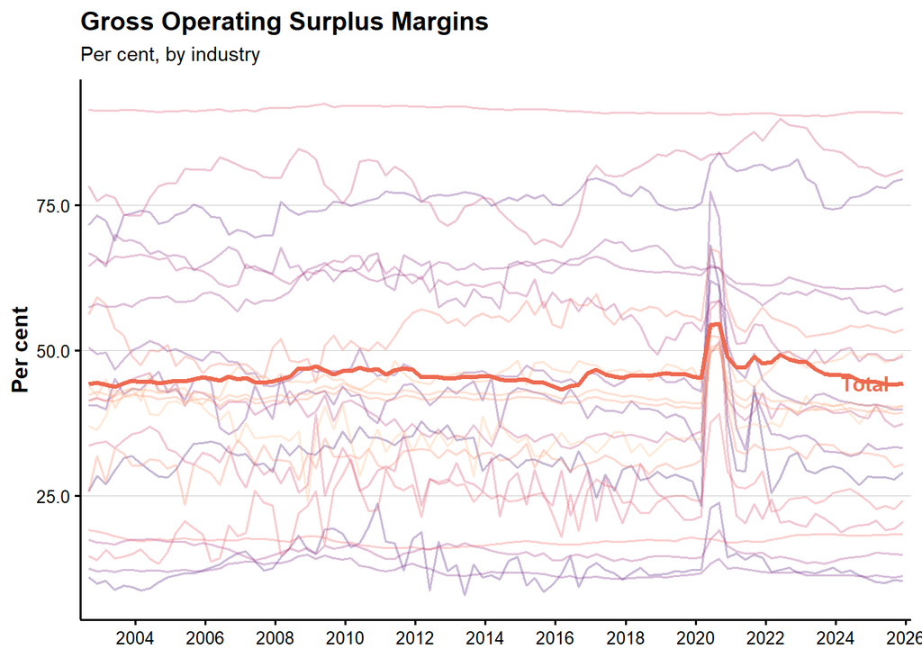

`GOP` margins across sectors are relatively more clustered than `GOS`. This may reflect that there is smaller variation in business profit across sectors compared to the surplus gained from production across sectors. the `GOP` Total aggregate sits just above the median, perhaps being skewed by the significant contributions of the mining sector (the top-most line).

## Variance Decomposition

As we have shown, the margins are skewed by large contributing sectors.

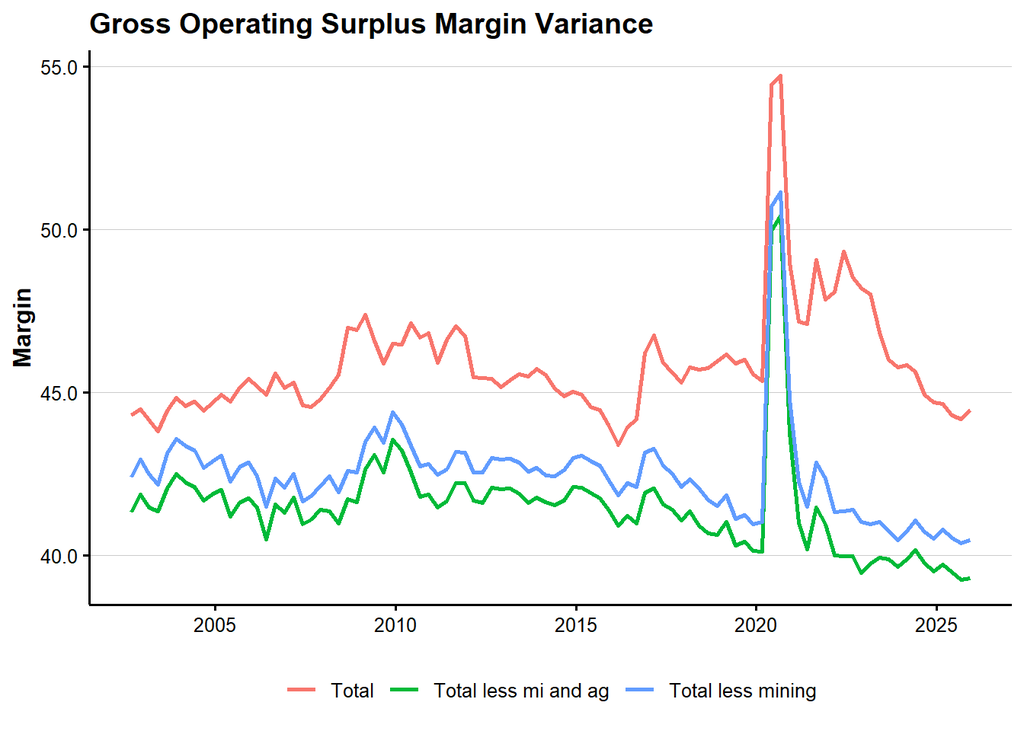

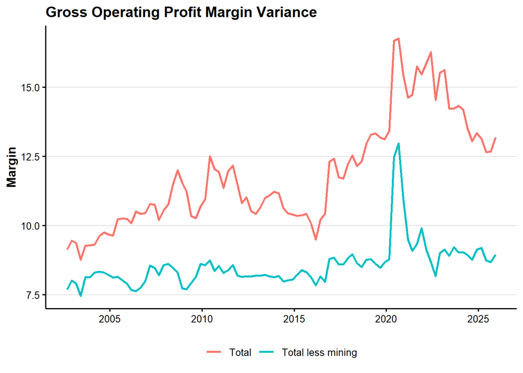

`GOP` does not account for the agricultural sector, making `Total less mining` (an aggregate subtracting the contributions of the mining sector) the closest comparison measure.

`GOP` becomes significantly reduced and less volatile after abstracting from the mining sector, signifying a more centralised margin measure. The same holds true for `GOS`, as removing mining reduces outlying spikes in the original `Total` series. Further abstraction from agriculture only reduces the level of the series, reflecting that the agricultural sector doesnt drive the shape of the time-series.

This legitimises our approach of using `Total less mining` as a true domestic margin proxy.

## Further Time Series Analysis

```r
gop_ts <- gop |>
  mutate(date = yearquarter(date)) |>
  as_tsibble(key = industry, index = date)

gos_ts <- gos |>
  mutate(date = yearquarter(date)) |>
  as_tsibble(key = industry, index = date)
```

### Seasonal Plots

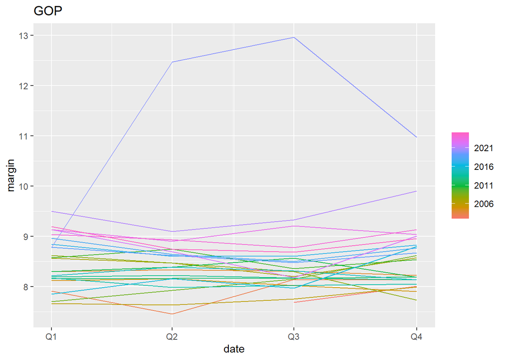

```r
gop_ts |>
  filter(industry == "Total less mining") |>
  gg_season(y = margin) + labs(title = "GOP")
```

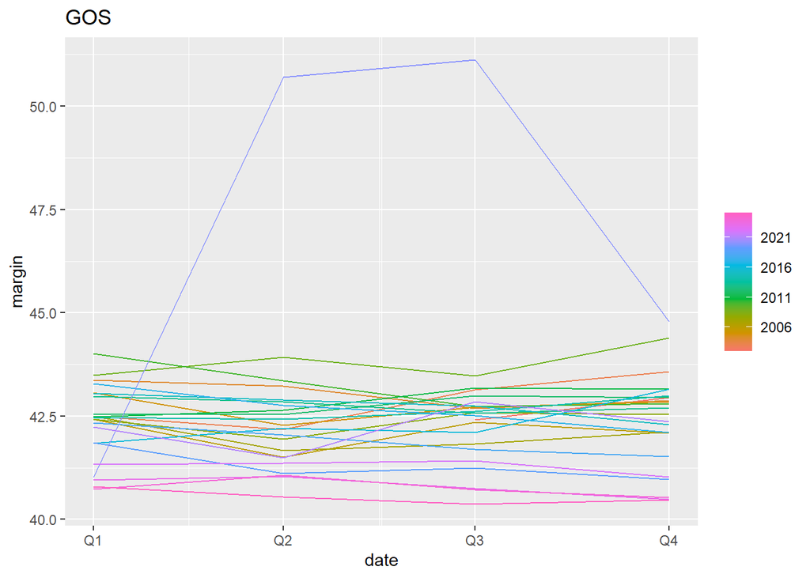

```r
gos_ts |>
  filter(industry == "Total less mining") |>
  gg_season(y = margin)+ labs(title = "GOS")
```

These seasonal plots visualise changes within a single year, overlaid across multiple years to allow for direct comparison.

`GOP` shows a small increase across time, following the general increase in macroeconomic variables over time. However, there is a significant spike occurring during 2020 (highlighted by the corresponding blue colour), the same holds true for `GOS`, highlighting that the COVID-19 period is a significant outlier for the series.

### Subseries plots

Subseries plots visualise the change in each quarter across the length of the time series, and are valuable to anaylse particular outliers in a series.

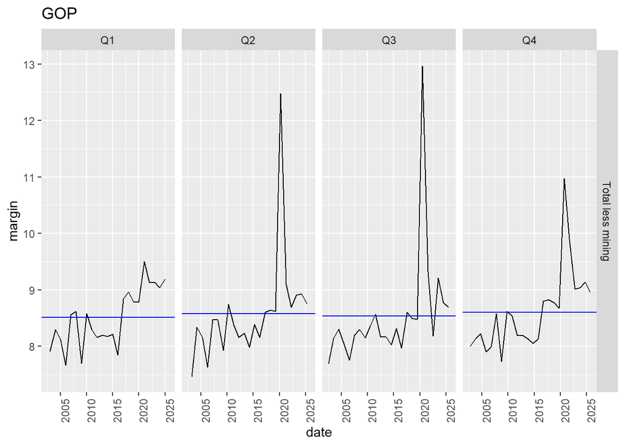

```r
gop_ts |>
  filter(industry == "Total less mining") |>
  gg_subseries(margin) + labs(title = "GOP")
```

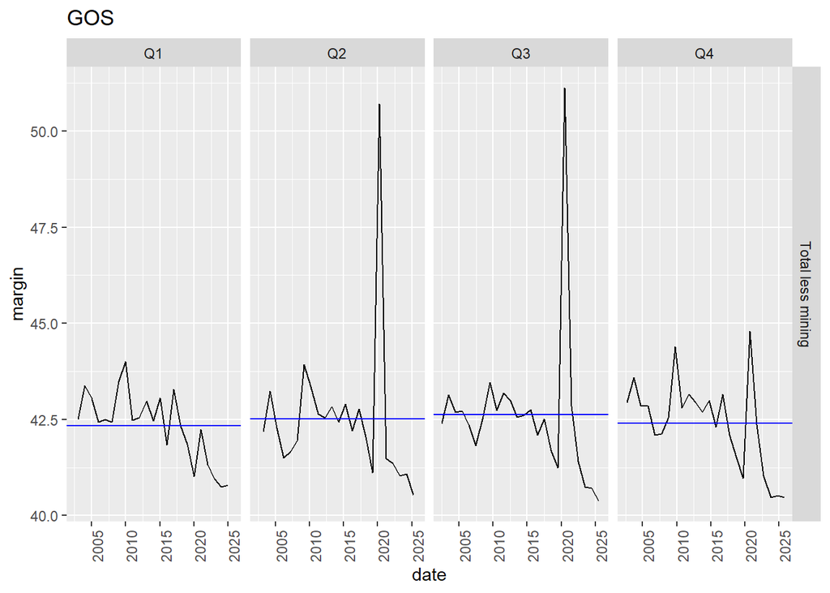

```r
gos_ts |>
  filter(industry == "Total less mining") |>
  gg_subseries(margin) + labs(title = "GOS")
```

`GOP` has a general increase across quarters over time. This is contrasted by the general decrease across quarters occurring in `GOS`. This distinction can help us understand the underlying drivers of the margins and how they may respond to changes in the business cycle, as they may reflect procyclical and countercyclical behaviour.  
The plots also help identify that the COVID-19 shock starts in Q2 of 2020, before subsiding in Q4 of the same year.

### STL Decomposition

An STL decomposition splits a time series into three additive components:

$$Y_t = T_t + S_t + R_t$$

Where: $Y_t$ is the observed series, $T_t$ (Trend-Cycle) is the long-term progression of the series, capturing the structural movement of margins while smoothing out high-frequency noise, $S_t$ captures the recurring intra-year seasonal fluctuations, and $R_t$ is the residual component. This remainder component captures stochastic “shocks” not captured by trend or seasonality.

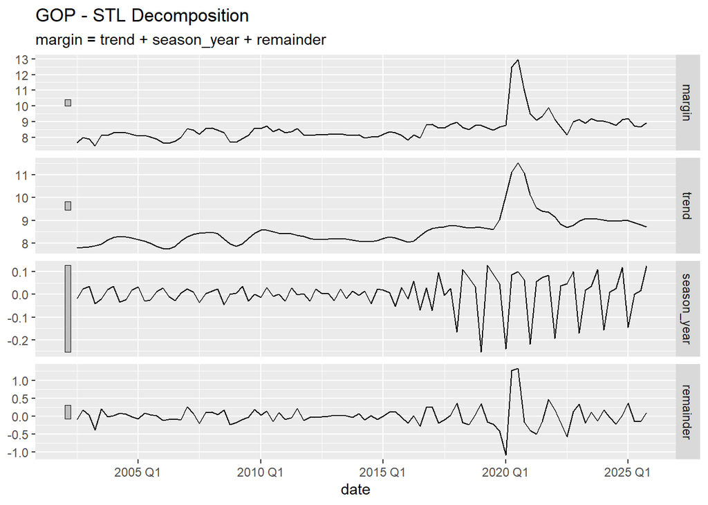

```r
gop_ts |>
  filter(industry == "Total less mining") |>
  model(STL(margin)) |>
  components() |>
  autoplot() + labs(title = "GOP - STL Decomposition")
```

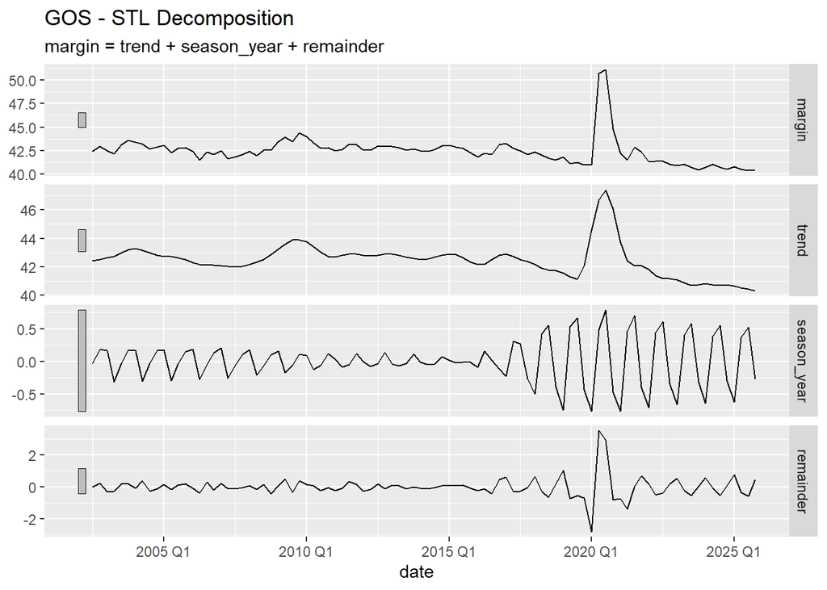

```r
gos_ts |>
  filter(industry == "Total less mining") |>
  model(STL(margin)) |>
  components() |>
  autoplot() + labs(title = "GOS - STL Decomposition")
```

GOP:

- **Trend:** The series exhibits a cyclical, wavy pattern that remained relatively stable until a significant spike during the COVID-19 pandemic; it has since reverted to its pre-pandemic trajectory.
- **Seasonality:** The data shows severe heteroskedasticity, with seasonal variance expanding well before the pandemic. This is an important insight, as it soldifies that the pandemic cannot be the sole driver of margin expansion.
- **Remainder:** Persistent patterns in the residuals indicate that the decomposition failed to capture all underlying variation from the original series - reflecting a potential for MA() modelling.

GOS:

- **Overall Dynamics:** The series mirrors the structural dynamics observed in the `GOP` decomposition.
- **Seasonality:** Seasonal amplitude tapers toward the middle of the series before expanding in later periods.

Both `GOP` and `GOS` margins exhibit cyclical trends with significant COVID-period spikes that have since normalised, alongside persistent residual patterns and heteroskedastic seasonality that expanded well before the pandemic.

# Business Cycle Indicators

Gross Domestic Product and Total Hours Worked follow a general linear trend across time, with a series break at 2020 reflecting the impacts of COVID-19.

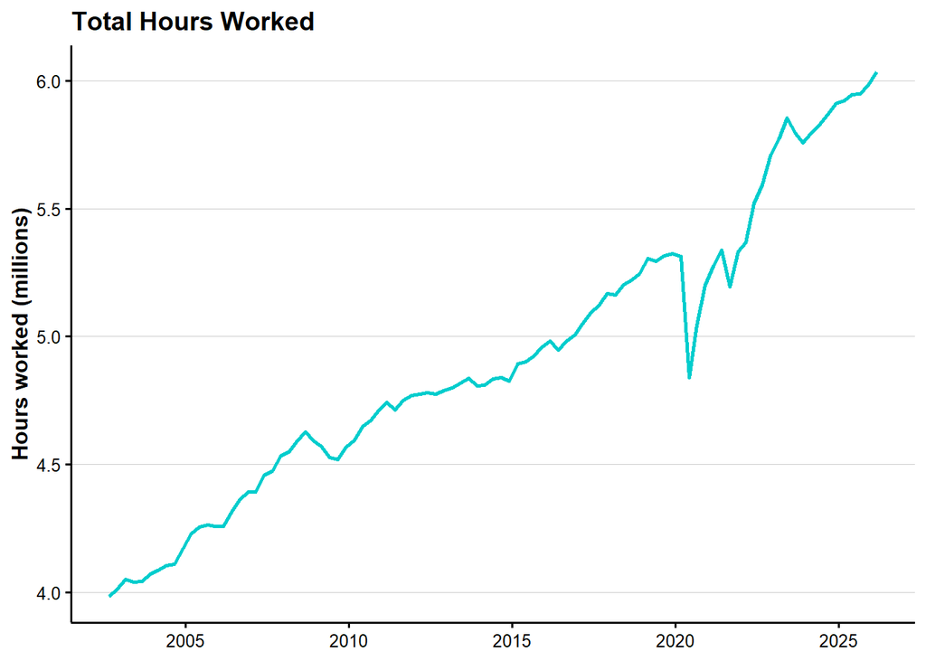

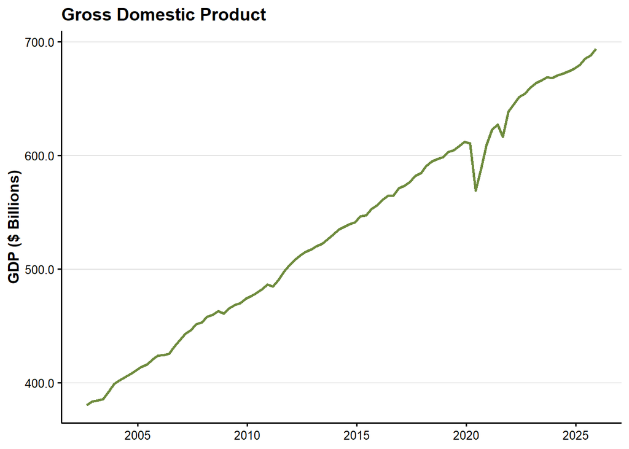

`THW` appears to be more volatile, potentially due to underlying dynamics in the labour market compared to `GDP` aggregates.

## Simple Transformations

To make margins and the business cycle indicators comparable, we need to transform the indicators in some way.

#### Log transformations

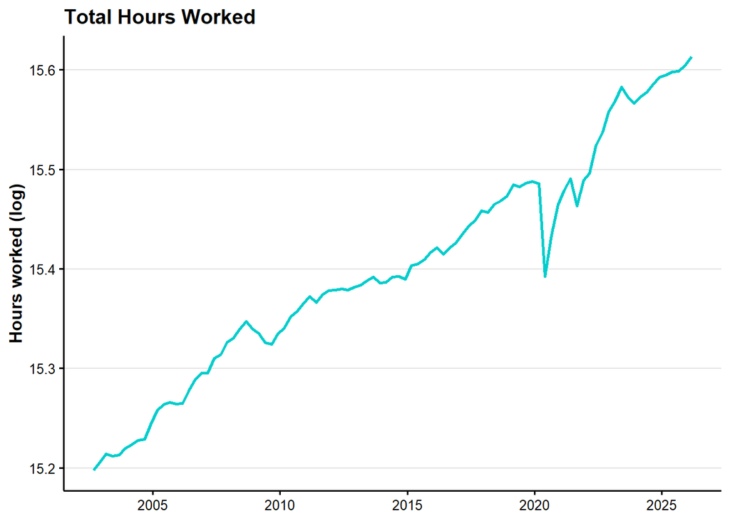

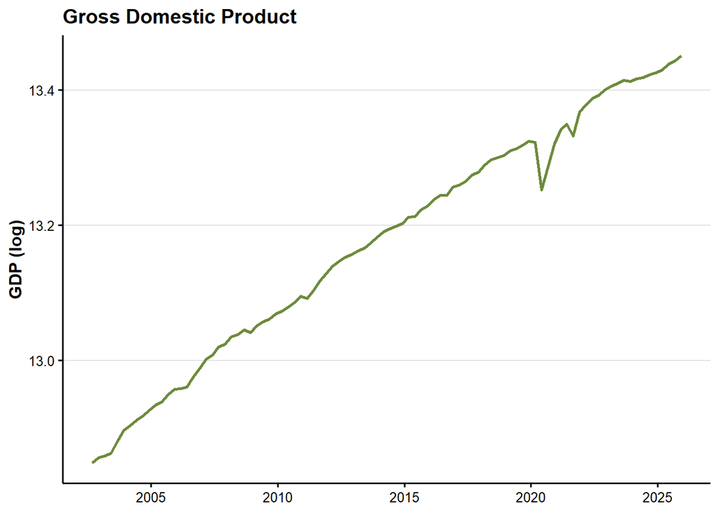

While this transformation does help stabilise the change in THW, it does little to extract any cyclical variation in GDP over time.

### Hodrick–Prescott (HP) Filter

To fully deconstruct the series into a testable cyclical component, we can use more advanced econometric techniques.

The HP filter decomposes a time series $y_t$ into a smooth long-term **trend** component $\tau_t$ and a short-term **cyclical** component $c_t$:

$$y_t = \tau_t + c_t$$

It does this by solving:

$$\min_{\{\tau_t\}} \sum_{t=1}^{T} (y_t - \tau_t)^2
+ \lambda \sum_{t=2}^{T-1} \left[ (\tau_{t+1} - \tau_t) - (\tau_t -
\tau_{t-1}) \right]^2$$

- First term: fit to the data
- Second term: smoothness of the trend
- $\lambda$: smoothing parameter

### Interpretation

- $\tau_t$: long-run trend
- $c_t = y_t - \tau_t$: business cycle (deviations from trend)

```r
library(mFilter)
library(tidyverse)
library(pracma)
hp_gdp <- mFilter::hpfilter(log(gdp$value), freq = 16000)

cycle <- hp_gdp$cycle
cycle_smooth <- movavg(cycle, n=4, type = "s")

hp_gdp <- gdp |>
  mutate(
    trend = hp_gdp$trend,
    cycle = hp_gdp$cycle,
    cycle_smooth = cycle_smooth
  )
```

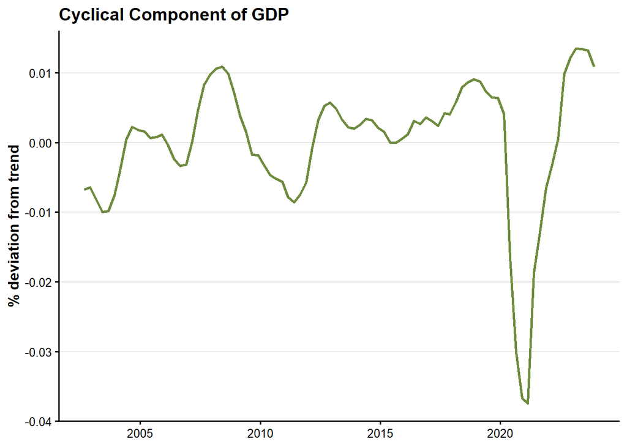

*The cyclical component has been smoothed on on a 4-period moving average for illustrative purposes.

The approximate cyclical component reflects % deviations from the trend of the series. In effect, it can be interpreted as a proxy for fluctuations in business activity after controlling for the usual increase in economic wealth over time. It reflects classical business cycle theory, as it contains a series of peaks and troughs which align with recessions and boom periods in the Australian economy. The COVID-19 downturn can be clearly seen, with the cycle falling far below zero. the pre-GFC mining boom is also reflected in a seasonal peak occurring in ~2008.

The HP filter, along with most econometric filters, have significant end-point problems which make the tails of the components inaccurate and jagged. It is important to remove these values from future research as they will skew results and do not reflect real economic patterns. The COVID-19 trough will also need to be controlled for given its significant deviation from the rest of the series.

[figure not shown]

# Appendix 1.A

### Industries

- Agriculture
- Mining
- Manufacturing
- Electricity, Gas, Water and Waste Services
- Construction
- Wholesale Trade
- Retail Trade
- Accommodation and Food Services
- Transport, Postal and Warehousing
- Information Media and Telecommunications
- Financial and Insurance Services
- Rental, Hiring and Real Estate Services
- Professional, Scientific and Technical Services
- Administrative and Support Services
- Arts and Recreation Services
- Other Services

### Aggregates

- Total
- Total less Mining
- Total less Mining and Agriculture